# NYC Subway Data Analysis by Long Nguyen

```python
%matplotlib inline

import matplotlib
import numpy as np
import matplotlib.pyplot as plt
```

```python
# Load the libraries

from math import log
from scipy.stats.stats import pearsonr
from pandas import *
from ggplot import *
from numpy import *
import statsmodels.api as sm
```

```python
# Load the data

df = pandas.read_csv("C:/Users/Long Nguyen/My-1st-Project/turnstile_data_master_with_weather.csv")
```

### Summary of numeric variables

```python
df.shape
```

```
(131951, 22)
```

```python
list(df.columns.values)
```

```
['Unnamed: 0',
 'UNIT',
 'DATEn',
 'TIMEn',
 'Hour',
 'DESCn',
 'ENTRIESn_hourly',
 'EXITSn_hourly',
 'maxpressurei',
 'maxdewpti',
 'mindewpti',
 'minpressurei',
 'meandewpti',
 'meanpressurei',
 'fog',
 'rain',
 'meanwindspdi',
 'mintempi',
 'meantempi',
 'maxtempi',
 'precipi',
 'thunder']
```

```python
# Structure of data

df = df.drop(df[[0]], axis = 1)

new_df = df

namelist = ['fog','rain','thunder', "Hour"]

for name in namelist:
    new_df[name] = new_df[name].astype('category')

new_df.describe()
```

|  | ENTRIESn_hourly | EXITSn_hourly | maxpressurei | maxdewpti | mindewpti | minpressurei | meandewpti | meanpressurei | meanwindspdi | mintempi | meantempi | maxtempi | precipi |
| --- | --- | --- | --- | --- | --- | --- | --- | --- | --- | --- | --- | --- | --- |
| count | 131951.000000 | 131951.000000 | 131951.000000 | 131951.000000 | 131951.000000 | 131951.000000 | 131951.000000 | 131951.000000 | 131951.000000 | 131951.000000 | 131951.000000 | 131951.000000 | 131951.000000 |
| mean | 1095.348478 | 886.890838 | 30.031894 | 57.241302 | 48.259013 | 29.892714 | 52.703526 | 29.965077 | 5.543065 | 56.169775 | 64.269729 | 71.769968 | 0.172276 |
| std | 2337.015421 | 2008.604886 | 0.125689 | 8.770891 | 11.305312 | 0.146384 | 9.943590 | 0.130461 | 1.982441 | 6.338875 | 6.568289 | 7.627218 | 0.429005 |
| min | 0.000000 | 0.000000 | 29.740000 | 39.000000 | 22.000000 | 29.540000 | 31.000000 | 29.640000 | 1.000000 | 46.000000 | 55.000000 | 58.000000 | 0.000000 |
| 25% | 39.000000 | 32.000000 | 29.960000 | 50.000000 | 38.000000 | 29.840000 | 45.000000 | 29.910000 | 5.000000 | 52.000000 | 60.000000 | 65.000000 | 0.000000 |
| 50% | 279.000000 | 232.000000 | 30.030000 | 57.000000 | 51.000000 | 29.910000 | 54.000000 | 29.960000 | 5.000000 | 54.000000 | 63.000000 | 71.000000 | 0.000000 |
| 75% | 1109.000000 | 847.000000 | 30.100000 | 64.000000 | 55.000000 | 29.970000 | 60.000000 | 30.050000 | 6.000000 | 60.000000 | 68.000000 | 78.000000 | 0.100000 |
| max | 51839.000000 | 45249.000000 | 30.310000 | 70.000000 | 66.000000 | 30.230000 | 68.000000 | 30.270000 | 12.000000 | 70.000000 | 78.000000 | 86.000000 | 2.180000 |

### Explore factor variables

```python
new_df.loc[:,["Hour","rain","thunder","fog"]].describe()
```

|  | Hour | rain | thunder | fog |
| --- | --- | --- | --- | --- |
| count | 131951 | 131951 | 131951 | 131951 |
| unique | 24 | 2 | 1 | 2 |
| top | 12 | 0 | 0 | 0 |
| freq | 9297 | 87847 | 131951 | 109902 |

Since there is only one unique value for thunder variable, we will exclude this variable because it do not provide any useful informaion for our analysis.

### Univariate analysis

Histogram of entries per hour

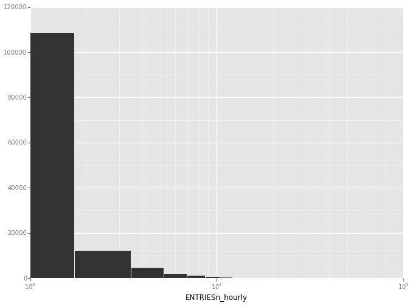

```python
ggplot(aes(x = 'ENTRIESn_hourly'),data=df) + geom_histogram() + scale_x_log()
```

```python
df["ENTRIESn_hourly"].describe()
```

```
count    131951.000000
mean       1095.348478
std        2337.015421
min           0.000000
25%          39.000000
50%         279.000000
75%        1109.000000
max       51839.000000
Name: ENTRIESn_hourly, dtype: float64
```

The graph shows that the distribution of entries per hour accross all stations is heavily skewed, with 75% of the recorded data shows less than 1109 entries per hour. This, however, does not mean that the majority of stations experience around 1109 entries per hour, because the amount of recorded data for each station is very different (as we will se below). This might cause the data to be biased towards stations that provide more data.

However, this data shows that it will be better if we use median as the central measurement in further statistical analysis in stead of mean or original values. Because the entries per hour is very spread out, arithmetic mean will be sensitive to extremely large values.

```python
grouped = df.groupby("UNIT", as_index = False)

days_at_unit = grouped["DATEn"].aggregate(np.count_nonzero)

days_at_unit.head()
```

|  | UNIT | DATEn |
| --- | --- | --- |
| 0 | R001 | 3309 |
| 1 | R002 | 3236 |
| 2 | R003 | 3014 |
| 3 | R004 | 3090 |
| 4 | R005 | 3069 |

```python
new = grouped["ENTRIESn_hourly"].aggregate(lambda x: np.percentile(x,75,axis=0))

new.describe()
```

|  | ENTRIESn_hourly |
| --- | --- |
| count | 465.000000 |
| mean | 2217.776882 |
| std | 2330.555081 |
| min | 0.000000 |
| 25% | 772.250000 |
| 50% | 1430.750000 |
| 75% | 2839.000000 |
| max | 17712.000000 |

The table shows the 75% percentile of entries per hour for each station. In order words, it seeks to see the typical entries per hour for each station. The data shows that most stations (75%) have less than 2839 entries most of the time. However, there are some special cases, where the majority of the time there are around 17712 entries per hour. I wonder if this is because the station experiences lots of trafic, or it just experience extremly high trafics during certain time?

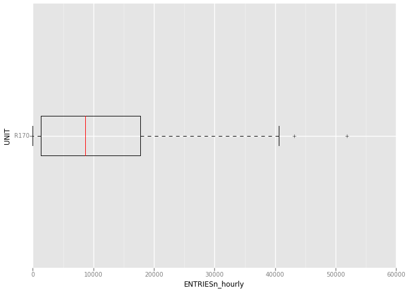

```python
station_idx = new['ENTRIESn_hourly'].idxmax()

station = new.loc[station_idx,:][0]

crowded_station = df

crowded_station.index = crowded_station["UNIT"]

crowded_station = crowded_station.loc[station,:]

ggplot(aes(y="UNIT", x="ENTRIESn_hourly"),data=crowded_station) + geom_boxplot()
```

```python
crowded_station["ENTRIESn_hourly"].describe()
```

```
count      243.000000
mean     11884.436214
std      11812.027096
min          0.000000
25%       1350.500000
50%       8678.000000
75%      17712.000000
max      51839.000000
Name: ENTRIESn_hourly, dtype: float64
```

The boxplot shows that the spread between data points is quite large, which suggests that this station doesn't experience high traffics all the time, but rather it experiences extremely high traffic (higher than other stations) at some specific time. This raises another problem: if we believe that stations have a certain effect on ridership (may be one station is in a much crowded area than the other), it will be hard to measure this effect, since the data is so spread out and inconsistent, which means that may be the station normally experience low traffic, but due to some external factors it experiences higher traffics than other stations sometimes. Thus, I am not going to include stations as one of the variables in my original model. Also, to overcome this problem, one can use the data that is more representative of each station (i.e. the spread is not so large). But I will do this later.

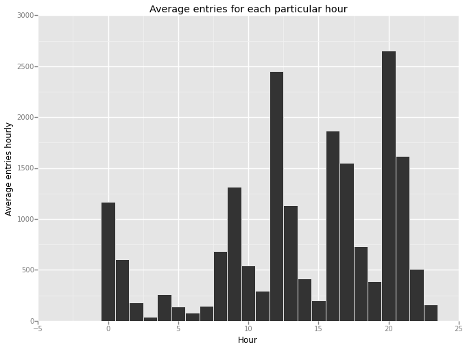

```python
grouped = df.groupby("Hour", as_index = False)

new = grouped["ENTRIESn_hourly"].aggregate(np.mean)

ggplot(aes(x="Hour",y="ENTRIESn_hourly"),data=new) + \
    geom_bar(stat = "identity") + \
    labs("Hour","Average entries hourly") + \
    ggtitle("Average entries for each particular hour")
```

I would like to see how various factors such as tempurature and pressure contributes to the variance in ridership. Looking at the variables, I think the features that should be included in the models are hour, the averages of moisture (meandewpti), temperature (meantempi), wind speed (meanwindspdi), pressure (meanpressurei), precipitation (precipi), rain, and fog. The reason I excluded the min or max measurements is because these measurements are used to calculate the average measurements; therefore, including all three will result in multi-colinearity. Also, when people decide whether or not to use subway, they tend to pay more attention to average weather condition rather than min or max measurements. Thus, it is appropriate not to include these measurements in the model.

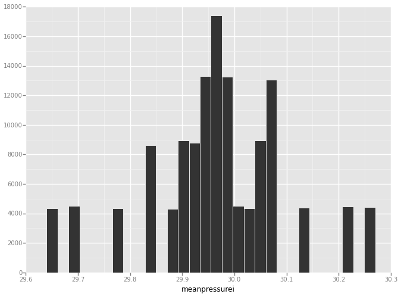

```python
ggplot(aes(x = 'meanpressurei'),data=df) + geom_histogram()
```

```python
df["meanpressurei"].describe()
```

```
count    131951.000000
mean         29.965077
std           0.130461
min          29.640000
25%          29.910000
50%          29.960000
75%          30.050000
max          30.270000
Name: meanpressurei, dtype: float64
```

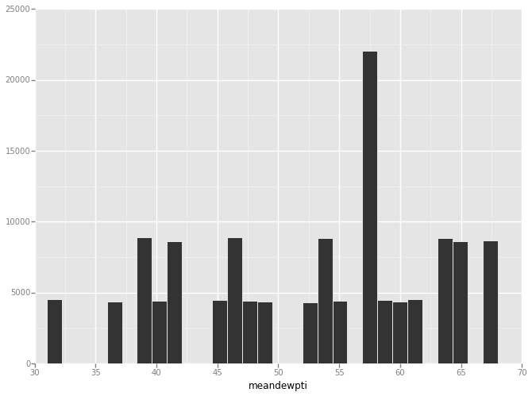

```python
ggplot(aes(x = 'meandewpti'),data=df) + geom_histogram()
```

```python
df["meandewpti"].describe()
```

```
count    131951.000000
mean         52.703526
std           9.943590
min          31.000000
25%          45.000000
50%          54.000000
75%          60.000000
max          68.000000
Name: meandewpti, dtype: float64
```

The distribution of mean dew point is evenly distributed with. The common dew point meaure is about 57 and the mean is around 53. I think the reason the data distributed so evenly is due to rounding.

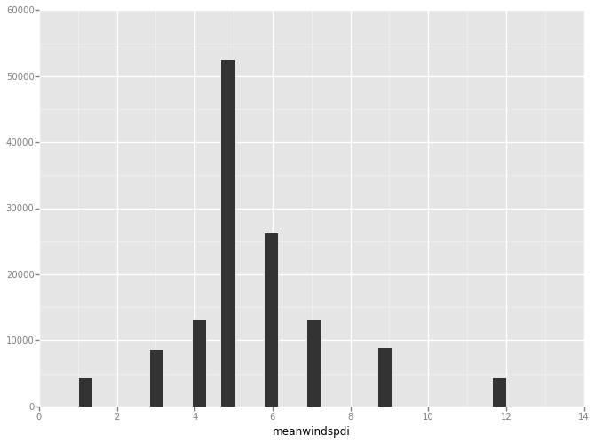

```python
ggplot(aes(x = 'meanwindspdi'),data=df) + geom_histogram()
```

```python
df["meanwindspdi"].describe()
```

```
count    131951.000000
mean          5.543065
std           1.982441
min           1.000000
25%           5.000000
50%           5.000000
75%           6.000000
max          12.000000
Name: meanwindspdi, dtype: float64
```

Mean wind speed is pretty normally distributed with mean value of 5.5

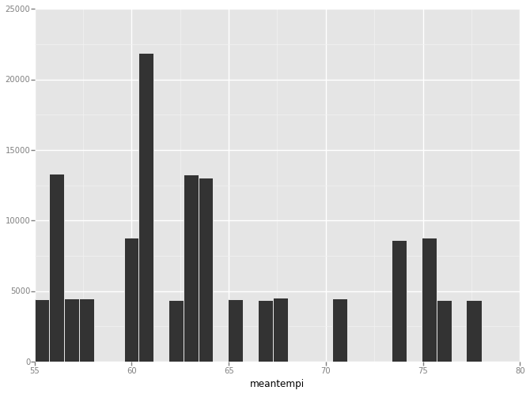

```python
ggplot(aes(x = 'meantempi'),data=df) + geom_histogram()
```

```python
df["meantempi"].describe()
```

```
count    131951.000000
mean         64.269729
std           6.568289
min          55.000000
25%          60.000000
50%          63.000000
75%          68.000000
max          78.000000
Name: meantempi, dtype: float64
```

The mean temperature measurement is positively skewed with the majority of values is less than 70.

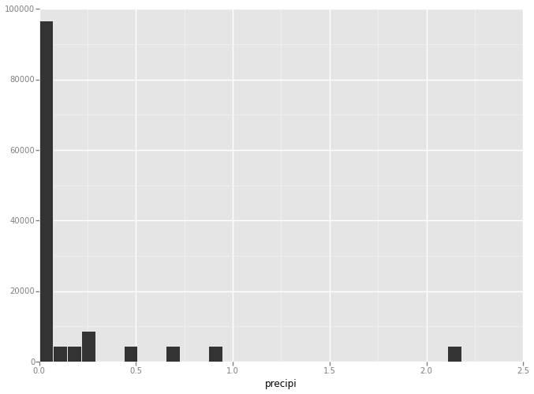

```python
ggplot(aes(x = 'precipi'),data=df) + geom_histogram()
```

```python
df["precipi"].describe()
```

```
count    131951.000000
mean          0.172276
std           0.429005
min           0.000000
25%           0.000000
50%           0.000000
75%           0.100000
max           2.180000
Name: precipi, dtype: float64
```

The precipitation measurement is positively skewed, since we have one meaurement that is too extreme (above 2) while the majority of data is below 1, I will consider this meausrement as an outlier and will exclude it in further analysis.

### Bivariate Analysis

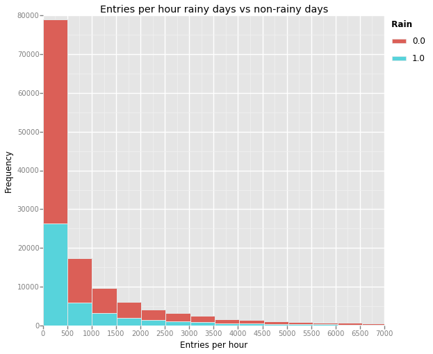

```python
ggplot(aes(x="ENTRIESn_hourly",fill="rain"),data = df) + \
    geom_histogram(binwidth = 500) + \
    ggtitle("Entries per hour rainy days vs non-rainy days") + \
    xlab("Entries per hour") + \
    ylab("Frequency") + \
    scale_x_continuous(limits = (0,7000))
```

From the above chart, we can see that the distribution of riders when it rains and when it doesn't rain are similar, with the majority of time there is less than 500 entries per hour. The difference in the frequencies may suggest that there are less rainy days than non-rainy days.

```python
df.groupby("rain").DATEn.nunique()
```

```
rain
0    20
1    10
Name: DATEn, dtype: int64
```

As we can see, the data shows that there is only 10 rainy days.

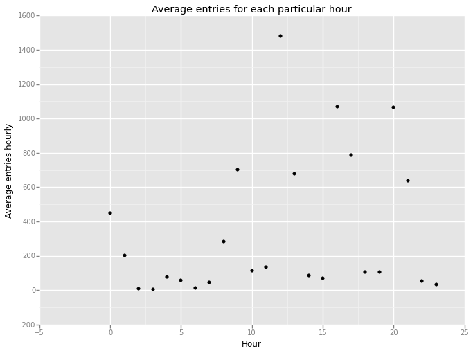

```python
grouped = df.groupby("Hour", as_index = False)

new = grouped["ENTRIESn_hourly"].aggregate(np.median)

ggplot(aes(x="Hour",y="ENTRIESn_hourly"),data=new) + \
    geom_point() + \
    labs("Hour","Average entries hourly") + \
    ggtitle("Average entries for each particular hour")
```

```python
pearsonr(df["ENTRIESn_hourly"],df["Hour"])
```

```
(0.17543044683295933, 0.0)
```

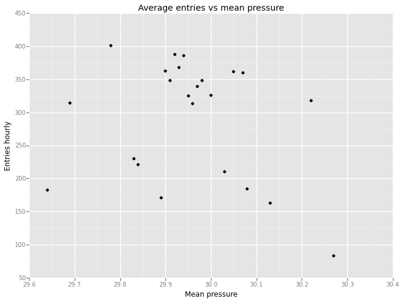

```python
grouped = df.groupby("meanpressurei", as_index = False)

new = grouped["ENTRIESn_hourly"].aggregate(np.median)

ggplot(aes(x="meanpressurei",y="ENTRIESn_hourly"),data=new) + \
    geom_point() + \
    labs("Mean pressure","Entries hourly") + \
    ggtitle("Average entries vs mean pressure")
```

```python
pearsonr(df["ENTRIESn_hourly"],df["meanpressurei"])
```

```
(-0.016128237261487318, 4.6589425056375821e-09)
```

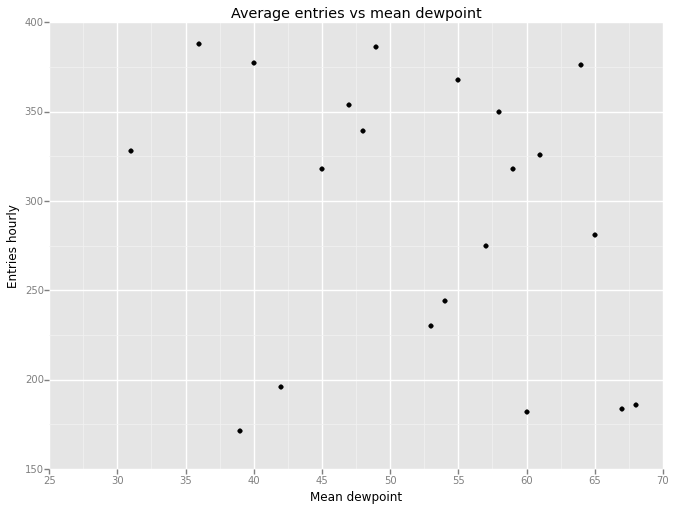

```python
grouped = df.groupby("meandewpti", as_index = False)

new = grouped["ENTRIESn_hourly"].aggregate(np.median)

ggplot(aes(x="meandewpti",y="ENTRIESn_hourly"),data=new) + \
    geom_point() + \
    labs("Mean dewpoint","Entries hourly") + \
    ggtitle("Average entries vs mean dewpoint")
```

```python
pearsonr(df["ENTRIESn_hourly"],df["meandewpti"])
```

```
(-0.016197867524249145, 3.9994673114641798e-09)
```

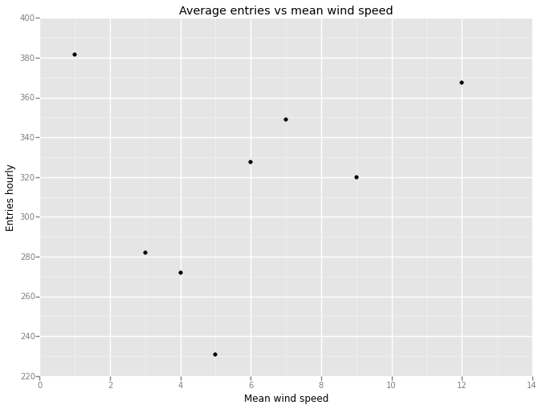

```python
grouped = df.groupby("meanwindspdi", as_index = False)

new = grouped["ENTRIESn_hourly"].aggregate(np.median)

ggplot(aes(x="meanwindspdi",y="ENTRIESn_hourly"),data=new) + \
    geom_point() + \
    labs("Mean wind speed","Entries hourly") + \
    ggtitle("Average entries vs mean wind speed")
```

```python
new = df[df.precipi <= 1]

pearsonr(new["ENTRIESn_hourly"],new["meanwindspdi"])
```

```
(0.024823707475706669, 7.4890331209136335e-19)
```

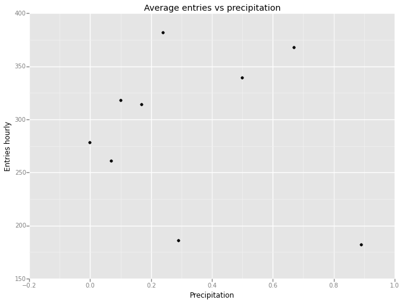

```python
grouped = new.groupby("precipi", as_index = False)

new2 = grouped["ENTRIESn_hourly"].aggregate(np.median)

ggplot(aes(x="precipi",y="ENTRIESn_hourly"),data=new2) + \
    geom_point() + \
    labs("Precipitation","Entries hourly") + \
    ggtitle("Average entries vs precipitation")
```

```python
new = df[df.precipi <= 1]

pearsonr(new["ENTRIESn_hourly"],new["precipi"])
```

```
(-0.01443668984259798, 2.5166038204203245e-07)
```

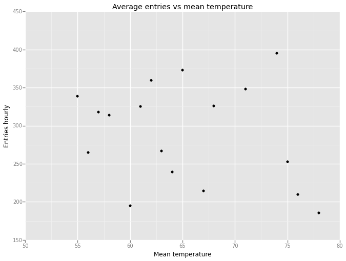

```python
grouped = df.groupby("meantempi", as_index = False)

new = grouped["ENTRIESn_hourly"].aggregate(np.median)

ggplot(aes(x="meantempi",y="ENTRIESn_hourly"),data=new) + \
    geom_point() + \
    labs("Mean temperature","Entries hourly") + \
    ggtitle("Average entries vs mean temperature")
```

```python
pearsonr(df["ENTRIESn_hourly"],df["meantempi"])
```

```
(-0.022796041448386175, 1.2145630079843014e-16)
```

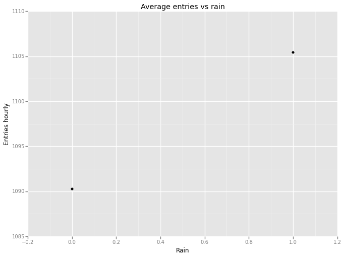

```python
grouped = df.groupby("rain", as_index = False)

new = grouped["ENTRIESn_hourly"].aggregate(np.mean)

ggplot(aes(x="rain",y="ENTRIESn_hourly"),data=new) + \
    geom_point() + \
    labs("Rain","Entries hourly") + \
    ggtitle("Average entries vs rain")
```

The statistical test that I used to analyze the NYC Subway data is the Mann-Whitney-U Test. This test is chosen after taking a look at the histogram of the number of entries in NYC subway in raining and not raining conditions. The histograms shows that the distributions of the number of entries does not follow a normal distribution. The Mann-Whitney-U test is sufficient when we want to see if the difference between too samples is statistically significant without assuming the normality of population distribution or taking large sample size to approximate normality.

I used the two-tail P values because we are guessing that the number of entries will be different when it rains. The null hypothesis is that when it rains, the number of people riding the subway will not be significantly different than when it doesn’t rain. That means if we were to count every person entering the subway when it rains and when it doesn’t rain, we will always find approximately the same number. Our alternate hypothesis is that there will be a difference.

In mathematical term: Null hypothesis: µR - µNR = 0 Alternate hypothesis: µR - µNR != 0

We will perform this test using significance level of α = 0.05. This makes our p-critical value smaller than 0.025 or larger than 0.025, which means that if our p value is within these ranges, we can reject the null hypothesis.

The result I got from Mann-Whitney-U test:

With rain mean = 1105.446 Without rain mean = 1090.279 U value: 1924409167.0 P value: 0.0249

These results mean that assuming the total number of people riding subway when it rains is not different from the total number of people riding subway when it doesn’t rain, the chance of selecting a sample difference of 15.167 (1105.446-1090.279) from the sampling distribution of sample means is only 0.0249 (2.49%), which is less than our threshold of 2.5%. Because of this, we can conclude that the difference in ridership does not happen by chance, but rather by an actual difference in the total number of people riding subway when it rains versus when it doesn’t rain. However, the p-value is very close to the p-critical value, which suggest that there is only a slight difference between the means.

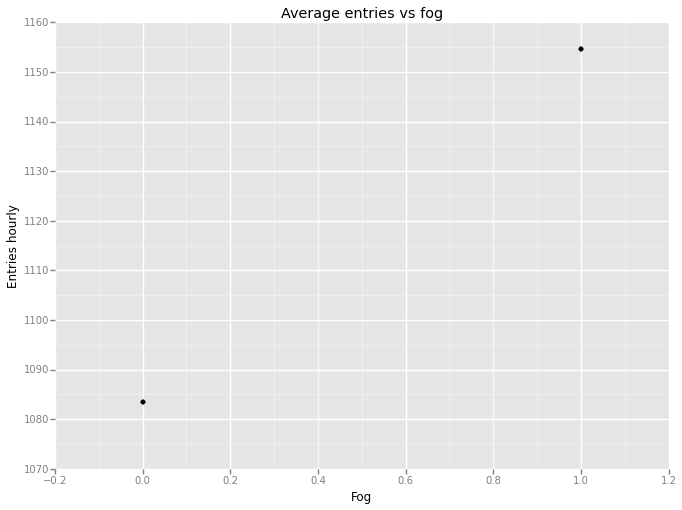

```python
grouped = df.groupby("fog", as_index = False)

new = grouped["ENTRIESn_hourly"].aggregate(np.mean)

ggplot(aes(x="fog",y="ENTRIESn_hourly"),data=new) + \
    geom_point() + \
    labs("Fog","Entries hourly") + \
    ggtitle("Average entries vs fog")
```

Since most of the independent variables doesn't show any sort of linear relationships with subway entries, I will fit a multivariate inear regression to see if all the independent variables working together can explain the variation in subway ridership.

```python
namelist = ['fog','rain','thunder', "Hour"]

for name in namelist:
    df[name] = df[name].astype('float')

def linear_regression(features, values):

    # Perform linear regression given a data set with an arbitrary number of features.

    features = sm.add_constant(features)
    model = sm.OLS(values,features)
    result = model.fit()
    intercept = result.params[0]
    params = result.params[1:]

    return result

def predictions(dataframe):

    features = dataframe[['meanpressurei','meandewpti','meanwindspdi','precipi','meantempi','Hour','rain','fog']]

    # Values
    values = dataframe['ENTRIESn_hourly']

    # Perform linear regression
    result = linear_regression(features,values)

    print result.summary()

predictions(df)
```

```
                            OLS Regression Results
==============================================================================
Dep. Variable:        ENTRIESn_hourly   R-squared:                       0.032
Model:                            OLS   Adj. R-squared:                  0.032
Method:                 Least Squares   F-statistic:                     547.4
Date:                Sat, 26 Dec 2015   Prob (F-statistic):               0.00
Time:                        01:20:01   Log-Likelihood:            -1.2086e+06
No. Observations:              131951   AIC:                         2.417e+06
Df Residuals:                  131942   BIC:                         2.417e+06
Df Model:                           8
Covariance Type:            nonrobust
=================================================================================
                    coef    std err          t      P>|t|      [95.0% Conf. Int.]
---------------------------------------------------------------------------------
const          7534.8650   1575.978      4.781      0.000      4445.977  1.06e+04
meanpressurei  -227.1907     52.146     -4.357      0.000      -329.396  -124.985
meandewpti       -1.3330      1.081     -1.234      0.217        -3.451     0.785
meanwindspdi     24.4489      3.582      6.826      0.000        17.429    31.469
precipi         -13.0973     19.882     -0.659      0.510       -52.065    25.871
meantempi        -5.4224      1.556     -3.484      0.000        -8.473    -2.372
Hour             59.4941      0.918     64.780      0.000        57.694    61.294
rain            -37.2217     19.857     -1.875      0.061       -76.141     1.697
fog             107.3338     21.396      5.017      0.000        65.398   149.269
==============================================================================
Omnibus:                   145377.175   Durbin-Watson:                   1.011
Prob(Omnibus):                  0.000   Jarque-Bera (JB):         15016031.623
Skew:                           5.642   Prob(JB):                         0.00
Kurtosis:                      54.028   Cond. No.                     2.24e+04
==============================================================================

Warnings:
[1] Standard Errors assume that the covariance matrix of the errors is correctly specified.
[2] The condition number is large, 2.24e+04. This might indicate that there are
strong multicollinearity or other numerical problems.
```

We have pretty low R-squared, which suggests that overall, the model did not do a good job in predicting the subway ridership. One interesting thing to note is that while the Mann-Whitney U test suggests that there is a significant difference in subway ridership between rain and non-rain condition, the regression suggests that rain is not an important predictor (since the p-value for its coefficient is quite large). How can this be? As we look in the graph between mean entries per hour and rain, we can see that there is indeed a difference between mean entries when it rains vs when it doesn't rain, but rain is a poor predictor for future ridership. The rain variable groups the entire data into two categories, thus it doesn't provide much information to explain the variation in entries per hour (which is a continuous quantity). Therefore, while being a good categorizer (we know that when it rains the number of people riding subway will be different), but we do not know for sure how different.

### Conclusion

From my analysis, it is shown that the number of people ride subway when it's raining is significantly different than when it's not raining. When we perform the Mann-Whitney-U test, we found out that the difference is statistically significant with p < 0.025. This has led me to conclude that the ridership when it’s raining is significantly different, although we do not know if the number of subway riders will increase or decrease.

Some shortcomings from the data are that the data doesn’t include enough features for an effective prediction. In reality, people rely on a lot of factors more than weather to decide whether or not to use the subway. Some variables that can be added to improve our analysis include the geographical area that each subway routes cover, a dummy variable which indicates if there are any special events going on near one of the stations, or the amount of cars purchased last year to predict the potential traffic. All of these variables would add much more insight and predictive capability in our model.

One of the shortcomings of our analysis is the low R-value and rounding of data. Our R value is only 3%, which means that only 3% of ridership is explained using the variables in our model. Part of the problem is that our model includes quite a lot of categorical variables such as rain, fog, and hour. The lack of variation in this variable makes it difficult to formulate predictions using quantitative regression.

Furthermore, the excessive rounding in raw data also destroy the variance in our data. A lot of data points overlap each other, which makes it hard to both visuallize the data and conduct a meaningful regression analysis. I would suggest rounding the data to three decimal places. Without these drawbacks, I believe we can draw much more insight from the NYC subway data.

### Work cited

https://www.edanzediting.com/blogs/statistics-anova-explained

http://www.stat.yale.edu/Courses/1997-98/101/anovareg.htm

http://stats.stackexchange.com/questions/44838/how-are-the-standard-errors-of-coefficients-calculated-in-a-regression/44841#44841

http://stats.stackexchange.com/questions/85943/how-to-derive-the-standard-error-of-linear-regression-coefficient

http://people.duke.edu/~rnau/testing.htm